Obsidian Vault

Stats blog

# Probabilistic view at multivariate analysis

## Factor analysis

Factor analysis

## Probabilistic PCA

Probabilistic interpretation of PCA

Probabilistic interpretation of PCA

Proof

## Probabilistic CCA

Probabilistic interpretation of CCA

Probabilistic interpretation of CCA

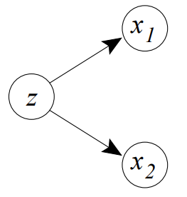

[A Probabilistic Interpretation of Canonical Correlation Analysis - Bach and Jordan - 2006](https://www.di.ens.fr/~fbach/probacca.pdf)

# Matrix perturbation

## Weyl's theorem

Weyl's theorem

Weyl's theorem

This is related to perturbation of eigenvalues. Let then eigenvalues of estimate well the ones of if is small.

## Principal angle

Principal angle

Principal angle

## Davis-Kahan theorem

Davis-Kahan theorem

Davis-Kahan theorem

Proof

[Blog: Matrix Perturbation and Davis-Kahan Theorem](https://trungvietvu.github.io/notes/2020/DavisKahan)[Blog: Davis-Kahan Theorem](http://yueqicao.top/2021/01/12/Davis-Kahan-s-Theorem/)

# Tensors

## Matrix products

Matrix products

Matrix products

### Kronecker product

Kronecker product

Kronecker product

Given and the *Kronecker product* is an matrix defined as

### Khatri–Rao product

Khatri–Rao

Khatri–Rao

Given and the *Khatri-Rao product* is an matrix defined as  
It is also called the "matching column-wise" Kronecker product.

### Hadamard product

Hadamard product

Hadamard product

Given and the *Hadamard product* is an matrix defined as

Properties

## Tensor operations

Tensor operations

Tensor operations

### Tensor structure

Tensor structure

Tensor structure

*Fibers* are defined by fixing every index but one. For instance, given a third-order tensor , we have column (mode-), row (mode-) and tube (mode-) fibers , and .

*Slices* are defined by fixing all but two indices. For instance, given a third-order tensor , we have horizontal, lateral and frontal slices , and .

The *mode- matricization* of a tensor is denoted by and arranges mode- fibers to be the columns of the resulting matrix.

### The n-mode product

The n-mode product

The n-mode product

Given a tensor and a matrix the *-mode product* is denoted by and is a tensor of size with elements

Properties

[Tensor Decompositions and Applications - Kolda and Bader - 2009](https://www.kolda.net/publication/TensorReview.pdf)

## CP decomposition

CP decomposition

CP decomposition

An -way tensor has a *rank-one* tensor if  
where represents the outer product.  
The *CP decomposition* of decomposes it into a sum of rank-one tensors as  
Here are the *factor matrices* with columns normalized to length one, and is the scaling vector.

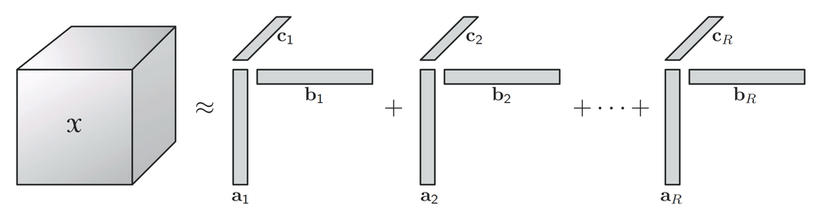

Note

*CP* stands for CANDECOMP (canonical decomposition)/PARAFAC (parallel factors).

### Uniqueness of CP

Uniqueness of CP

Uniqueness of CP

*Uniqueness* of CP decomposition means that this is the only possible combination of rank-one tensors that sums to with exception of the scaling  
and permutation  
A sufficient condition for CP uniqueness is  
Here is the *k-rank* of a matrix defined as the maximum value such that any columns are linearly independent.

### CP-ALS

CP-ALS

CP-ALS

A more general algorithm for computing a CP decomposition for an th-order tensor with components is provided below.

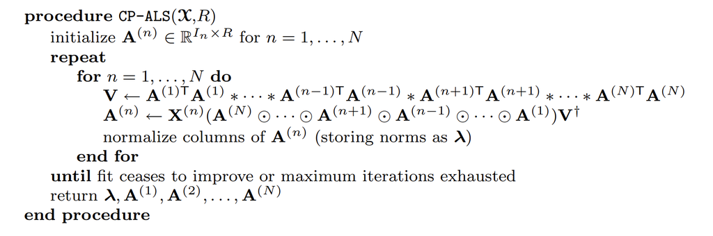

[Tensor Decompositions and Applications - Kolda and Bader - 2009](https://www.kolda.net/publication/TensorReview.pdf)

## Tensor rank

Tensor rank

Tensor rank

The smallest number of rank-one tensors that generate is called the *tensor rank*, denoted . This is the same as the smallest number of components in an exact CP decomposition.

Properties

- The components of the best rank- approximation may not be solved for sequentially (unlike matrix case).
- The best rank- approximation may not exits.

A tensor is *degenerate* is it may be approximated arbitrary well by a factorization of lower rank.

For instance, for a rank-three tensor there can be a sequence of rank-two tensors that provide increasingly better estimates. As the set of rank-two tensors is open they may converge to of rank other than two.

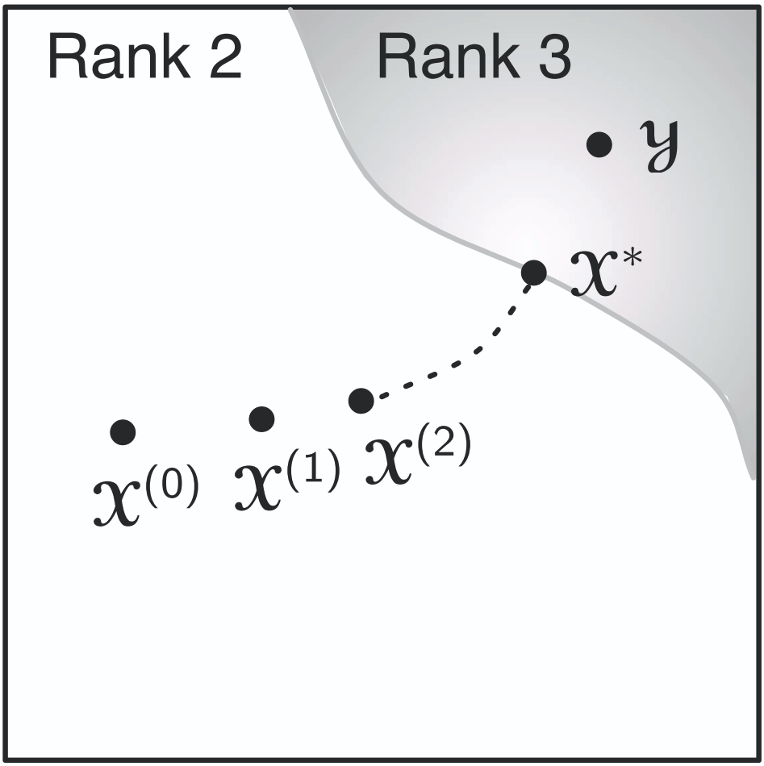

*Border rank* is defined as the minimum number of rank-one tensors that are sufficient to approximate the given tensor with arbitrarily small nonzero error:  
Clearly, .

The n-rank

The n-rank

Consider an -way tensor . The *n-rank* of , denoted by , is the column rank of . In other words, the dimension of the vector space spanning mode- fibers.

Let then we say that is a *rank- tensor*.

[Tensor Decompositions and Applications - Kolda and Bader - 2009](https://www.kolda.net/publication/TensorReview.pdf)

## Tucker decomposition

Tucker decomposition

Tucker decomposition

It decomposes a tensor into a core tensor multiplied by a matrix along each mode. If in an -way tensor then the *Tucker model* is  
Usually, are assumed to be columnwise orthogonal and is called the *core tensor*.

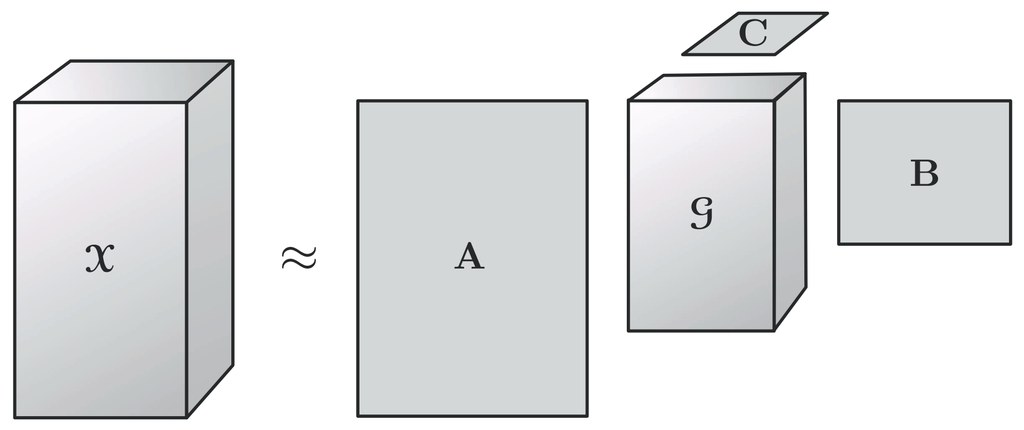

Properties

### HOSVD

HOSVD

HOSVD

One way to compute Tucker decomposition is through *higher-order SVD (HOSVD)*.

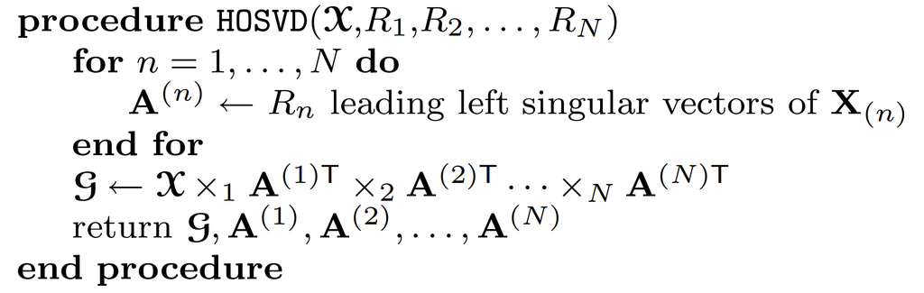

If then the result is called *truncated HOSVD*. The truncated HOSVD is not optimal in terms of giving the best fit as measured by the norm of the difference.

### HOOI

HOOI

HOOI

This can be done via alternating proceedure

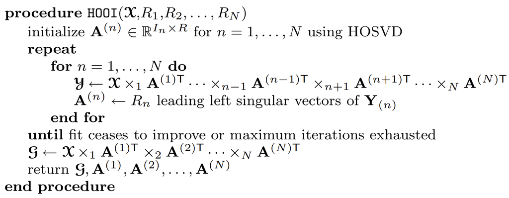

The HOOI theory is described in  
[Tensor SVD: Statistical and Computational Limits - Zhang and Xia - 2020](https://arxiv.org/pdf/1703.02724)

[Tensor Decompositions and Applications - Kolda and Bader - 2009](https://www.kolda.net/publication/TensorReview.pdf)